# Titanic Shuffle

ThinkData Ed

Directions: Follow along with the slides.  
Space, Click, Right Arrow or swipe left to move to the next slide.

# Let’s get started

We first need to load the titanic dataset onto our Environment. To do this type the following command on your console and press enter on your keyboard:

```r
data(titanic)
```

To view the data, type the following command (make sure to capitalize):

```r
View(titanic)
```

Peruse the data. How many passengers are in this dataset? How many variables (columns) are in this dataset?

# Titanic

To find the mean fare for passengers on the Titanic type the following command:

```r
mean(~fare, data = titanic)
```

Don’t be alarmed about the Warning message. It is just letting you know that some of the fares for the passengers were missing.

To find the mean fare of survivors and non-survivors separately, type the following:

```r
mean(~fare | survived, data = titanic)
```

[output not shown]

The output shows that on average, survivors paid about 27 more pounds than non-survivors. Is this enough evidence to say that those that paid a higher fare were more likely to survive?

# Stronger Evidence

In statistics a formal probability test would be applied to determine if a difference of 27 pounds was significant. In data science, we will apply a permutations test using shuffling.

The code below will allow you to view specific columns in a dataset.

```r
View(select(titanic, c(name, fare, survived)))
```

The code below will add a new variable to the titanic dataframe called `alt_survived`. This new column shows what might have happened in an alternate universe where the Titanic sails again but this time survival is determined via a lottery system.

After running the code below, the number of variables in the titanic dataframe should change from 8 to 9 in the Environment Pane.

```r
titanic<-mutate(titanic, alt_survived = shuffle(survived))
```

Let’s view the outcomes for this shuffled data.

```r
View(select(titanic, c(name, fare, survived, alt_survived)))
```

Let’s compare the mean fare between survivors and non-survivors for this shuffle.

```r
mean(~fare | alt_survived,  data = titanic)
```

What is the difference in mean fares (survivors minus non-survivors)?

Tip: The console can be used as a calculator.

# More Shuffles

We need to perform many permutations of this dataset to determine how common a difference of 27 pounds occurs when survival is based on a lottery system.

The code below creates a new dataframe in the Environment Pane. Each row represents a simulation of holding a lottery to determine survival.

```r
shuffled_outcomes <- do(500) * mean(~fare | shuffle(survived), data = titanic)
```

Now let’s view this new dataframe.

```r
View(shuffled_outcomes)
```

Although you cannot see the actual outcomes of each passenger, you can see the mean fares of survivors and non-survivors for each of the 500 simulations.

# Model

The code below will create a new column in our shuffled_outcomes dataframe which shows how much the mean fare differed between survivors and non-survivors. If you look at the Environment after running the code, the shuffled_outcomes data frame will contain three variables instead of 2.

```r
shuffled_outcomes <- mutate(shuffled_outcomes, diff_fares = Yes - No)
```

```r
View(shuffled_outcomes)
```

Using this new variable we will create a histogram which serves as a model displaying the typical difference in mean fares between survivors and non-survivors when survival is determined by chance alone.

NOTE: When you run the code below, it will revert you to the Plots pane. To get back to the lab slides, click on the Viewer tab which is to the right of the Plots pane.

```r
histogram(~diff_fares, data = shuffled_outcomes)
```

This chance model shows what removing all bias (favoritism) in regards to survival looks like. Notice that it is centered at zero. Why is that?

It should be centered at zero because when we randomly assign survival, the randomization process, for the most part, creates very similar groups. In this case similar groups in terms of the amount they paid for their fare. The groups were comprised of wealthy and not so wealthy. In the 500 simulations, the smallest difference was around -10 pounds and the largest was around 10 pounds.

# Interpretation

Where in this model do we see a difference of 27 pounds? Since a difference of 27 pounds was a rare permutation, this provides strong evidence that people that paid a higher fare were more likely to survive.

[figure not shown]

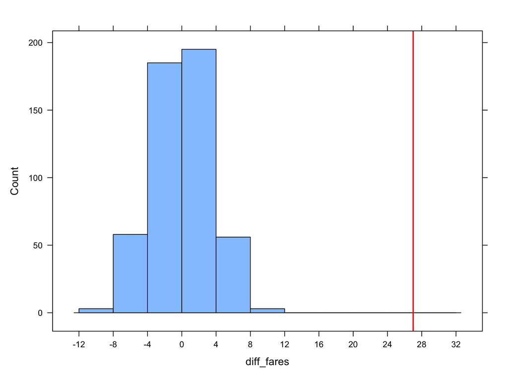

```r
add_line(vline=27)
```